# **Final Tutorial: The Data Science Process**

Dimitri Deychakiwsky

Alex Berlinger

Josh Kofsky

*Data Science* consists of a certain set of tasks that convert raw data to human readable information. The data science pipeline consists of data curation, parsing, and management; exploratory data analysis; hypothesis testing and machine learning to provide analysis. In this tutorial, we will take you through the five major data steps every data scientist must do for a successful project.

#### Here are the following steps:

1. We will **find** and **collect** data.
2. We will **process** the data, **tidy** the data, and deal with **missing data**.
3. We will do **exploratory analysis** & data **vizualization**.
4. We will perform **analysis**, **hypothesis testing**, and **machine learning**.
5. We will gain **insight** & discuss **policy decision**.

[figure not shown]

## Step 1: Find and Collect Data

Each project should have an end goal. You should be *solving some sort of problem* or *looking for some sort of intuition about this data*. Finding relevant data is the first implied step.

### What data will we need?

We will need data that is from a reliable and accurate source. Incorrect data is a data scientist's nightmare. We are going to be making judgements and predictions based on the data we collect, so we must make sure the data is authentic and accurate. Most importantly, you need data that is revelant to the problem you are trying to solve.

### Where will we find it?

There are many reputable sources out there, but for the purposes of this tutorial we will be using data from the University of California, Irvine's websute. An overview of the data we will be using can be found [here](http://archive.ics.uci.edu/ml/datasets/Communities+and+Crime). Institutes of higher education along with government websites tend to have the most reliable and accurate data.

### How will we collect it?

We will be using Jupyter's i-Python-Notebook-file system, using the Python programming language, Python Data Analysis Library (Pandas), a fundamental package for scientific computing with Python called NumPy, and any other scientific libraries that we can import to help process and analyze the data.

[figure not shown]

#### The following code can be used to pull this data off the UCI website and put it into a Pandas DataFrame.

We chose a set that combines socio-economic data from the US census, law enforcement data, and crime data from the FBI. We found this dataset particularly interesting because, as we will show you later, you can predict crime rates based on specific features. A priori, there is no reason to assume this data is linear or any one given feature can have significant prediction power.

Notes about the data we selected:

- Data is described below based on original values. All numeric data was normalized into the decimal range 0.00-1.00 using an unsupervised, equal-interval binning method.
- Attributes retain their distribution and skew (e.g. the population attribute has a mean value of 0.06 because most communities are small). I.e. An attribute described as 'mean people per household' is actually the normalized (0-1) version of that value.

```python
import pandas as pd
import numpy as np
import matplotlib.pyplot as plt

columns = ["state","county","community","communityname","fold","population","householdsize","racepctblack","racePctWhite","racePctAsian","racePctHisp","agePct12t21","agePct12t29","agePct16t24","agePct65up","numbUrban","pctUrban","medIncome","pctWWage","pctWFarmSelf","pctWInvInc","pctWSocSec","pctWPubAsst","pctWRetire","medFamInc","perCapInc","whitePerCap","blackPerCap","indianPerCap","AsianPerCap","OtherPerCap","HispPerCap","NumUnderPov","PctPopUnderPov","PctLess9thGrade","PctNotHSGrad","PctBSorMore","PctUnemployed","PctEmploy","PctEmplManu","PctEmplProfServ","PctOccupManu","PctOccupMgmtProf","MalePctDivorce","MalePctNevMarr","FemalePctDiv","TotalPctDiv","PersPerFam","PctFam2Par","PctKids2Par","PctYoungKids2Par","PctTeen2Par","PctWorkMomYoungKids","PctWorkMom","NumIlleg","PctIlleg","NumImmig","PctImmigRecent","PctImmigRec5","PctImmigRec8","PctImmigRec10","PctRecentImmig","PctRecImmig5","PctRecImmig8","PctRecImmig10","PctSpeakEnglOnly","PctNotSpeakEnglWell","PctLargHouseFam","PctLargHouseOccup","PersPerOccupHous","PersPerOwnOccHous","PersPerRentOccHous","PctPersOwnOccup","PctPersDenseHous","PctHousLess3BR","MedNumBR","HousVacant","PctHousOccup","PctHousOwnOcc","PctVacantBoarded","PctVacMore6Mos","MedYrHousBuilt","PctHousNoPhone","PctWOFullPlumb","OwnOccLowQuart","OwnOccMedVal","OwnOccHiQuart","RentLowQ","RentMedian","RentHighQ","MedRent","MedRentPctHousInc","MedOwnCostPctInc","MedOwnCostPctIncNoMtg","NumInShelters","NumStreet","PctForeignBorn","PctBornSameState","PctSameHouse85","PctSameCity85","PctSameState85","LemasSwornFT","LemasSwFTPerPop","LemasSwFTFieldOps","LemasSwFTFieldPerPop","LemasTotalReq","LemasTotReqPerPop","PolicReqPerOffic","PolicPerPop","RacialMatchCommPol","PctPolicWhite","PctPolicBlack","PctPolicHisp","PctPolicAsian","PctPolicMinor","OfficAssgnDrugUnits","NumKindsDrugsSeiz","PolicAveOTWorked","LandArea","PopDens","PctUsePubTrans","PolicCars","PolicOperBudg","LemasPctPolicOnPatr","LemasGangUnitDeploy","LemasPctOfficDrugUn","PolicBudgPerPop","ViolentCrimesPerPop"]
data = pd.read_csv("http://archive.ics.uci.edu/ml/machine-learning-databases/communities/communities.data", names = columns)
data.head()
```

|  | state | county | community | communityname | fold | population | householdsize | racepctblack | racePctWhite | racePctAsian | ... | LandArea | PopDens | PctUsePubTrans | PolicCars | PolicOperBudg | LemasPctPolicOnPatr | LemasGangUnitDeploy | LemasPctOfficDrugUn | PolicBudgPerPop | ViolentCrimesPerPop |
| --- | --- | --- | --- | --- | --- | --- | --- | --- | --- | --- | --- | --- | --- | --- | --- | --- | --- | --- | --- | --- | --- |
| 0 | 8 | ? | ? | Lakewoodcity | 1 | 0.19 | 0.33 | 0.02 | 0.90 | 0.12 | ... | 0.12 | 0.26 | 0.20 | 0.06 | 0.04 | 0.9 | 0.5 | 0.32 | 0.14 | 0.20 |
| 1 | 53 | ? | ? | Tukwilacity | 1 | 0.00 | 0.16 | 0.12 | 0.74 | 0.45 | ... | 0.02 | 0.12 | 0.45 | ? | ? | ? | ? | 0.00 | ? | 0.67 |
| 2 | 24 | ? | ? | Aberdeentown | 1 | 0.00 | 0.42 | 0.49 | 0.56 | 0.17 | ... | 0.01 | 0.21 | 0.02 | ? | ? | ? | ? | 0.00 | ? | 0.43 |
| 3 | 34 | 5 | 81440 | Willingborotownship | 1 | 0.04 | 0.77 | 1.00 | 0.08 | 0.12 | ... | 0.02 | 0.39 | 0.28 | ? | ? | ? | ? | 0.00 | ? | 0.12 |
| 4 | 42 | 95 | 6096 | Bethlehemtownship | 1 | 0.01 | 0.55 | 0.02 | 0.95 | 0.09 | ... | 0.04 | 0.09 | 0.02 | ? | ? | ? | ? | 0.00 | ? | 0.03 |

5 rows × 128 columns

The Python code below first sorts the dataframe rows by whichever attributes are given to the function. In this case, we decided to sort on householdsize and population. Sorting data is important for many real-world applications.

Next, we drop four attributes from our dataframe. The reason we drop these attributes is that they represent geographical location only and not meaningful data to predict crime.

Note: throughout this tutorial, we try to do as many dataframe processing in-place, to avoid unnecessary overhead. That can help ease the processing space and time when working with extremely large datasets.

```python
data = data.sort_values(ascending=False, by=["householdsize","population"])

data.drop(['state','county','community','fold'],1, inplace=True)

data.head(20)
```

|  | communityname | population | householdsize | racepctblack | racePctWhite | racePctAsian | racePctHisp | agePct12t21 | agePct12t29 | agePct16t24 | ... | LandArea | PopDens | PctUsePubTrans | PolicCars | PolicOperBudg | LemasPctPolicOnPatr | LemasGangUnitDeploy | LemasPctOfficDrugUn | PolicBudgPerPop | ViolentCrimesPerPop |
| --- | --- | --- | --- | --- | --- | --- | --- | --- | --- | --- | --- | --- | --- | --- | --- | --- | --- | --- | --- | --- | --- |
| 1187 | SantaAnacity | 0.46 | 1.0 | 0.05 | 0.51 | 0.60 | 1.00 | 0.58 | 0.79 | 0.58 | ... | 0.08 | 0.91 | 0.48 | 0.23 | 0.13 | 0.82 | 0.5 | 0.59 | 0.19 | 0.45 |
| 1710 | Laredocity | 0.18 | 1.0 | 0.00 | 0.56 | 0.02 | 1.00 | 0.67 | 0.65 | 0.45 | ... | 0.09 | 0.31 | 0.20 | 0.08 | 0.01 | 0.69 | 0 | 0.44 | 0.04 | 0.28 |
| 243 | ElMontecity | 0.15 | 1.0 | 0.02 | 0.42 | 0.72 | 1.00 | 0.60 | 0.72 | 0.50 | ... | 0.03 | 0.94 | 0.36 | 0.01 | 0.04 | 0.9 | 1 | 1.00 | 0.19 | 0.54 |
| 396 | Brownsvillecity | 0.14 | 1.0 | 0.00 | 0.77 | 0.02 | 1.00 | 0.72 | 0.65 | 0.45 | ... | 0.08 | 0.30 | 0.13 | 0.05 | 0.02 | 0.89 | 0 | 0.50 | 0.07 | 0.39 |
| 726 | Comptoncity | 0.13 | 1.0 | 1.00 | 0.00 | 0.12 | 0.81 | 0.61 | 0.66 | 0.45 | ... | 0.03 | 0.74 | 0.36 | 0.05 | 0.05 | 0.61 | 0.5 | 0.98 | 0.22 | 0.90 |
| 1171 | SouthGatecity | 0.12 | 1.0 | 0.03 | 0.11 | 0.10 | 1.00 | 0.62 | 0.69 | 0.49 | ... | 0.02 | 0.98 | 0.45 | ? | ? | ? | ? | 0.00 | ? | 0.45 |
| 471 | Sandycity | 0.10 | 1.0 | 0.00 | 0.96 | 0.10 | 0.05 | 0.67 | 0.52 | 0.26 | ... | 0.06 | 0.31 | 0.13 | ? | ? | ? | ? | 0.00 | ? | 0.05 |
| 1669 | BaldwinParkcity | 0.10 | 1.0 | 0.05 | 0.32 | 0.75 | 1.00 | 0.62 | 0.69 | 0.47 | ... | 0.02 | 0.88 | 0.23 | ? | ? | ? | ? | 0.00 | ? | 0.25 |
| 354 | Oremcity | 0.09 | 1.0 | 0.00 | 0.95 | 0.09 | 0.05 | 0.66 | 0.64 | 0.40 | ... | 0.05 | 0.31 | 0.12 | ? | ? | ? | ? | 0.00 | ? | 0.03 |
| 386 | Chinocity | 0.08 | 1.0 | 0.19 | 0.50 | 0.21 | 0.67 | 0.59 | 0.70 | 0.48 | ... | 0.05 | 0.29 | 0.03 | ? | ? | ? | ? | 0.00 | ? | 0.39 |
| 998 | Lynwoodcity | 0.08 | 1.0 | 0.46 | 0.00 | 0.13 | 1.00 | 0.65 | 0.72 | 0.50 | ... | 0.01 | 1.00 | 0.35 | ? | ? | ? | ? | 0.00 | ? | 1.00 |
| 687 | HuntingtonParkcity | 0.07 | 1.0 | 0.02 | 0.00 | 0.11 | 1.00 | 0.63 | 0.76 | 0.55 | ... | 0.01 | 1.00 | 0.80 | ? | ? | ? | ? | 0.00 | ? | 0.62 |
| 1350 | Rosemeadcity | 0.07 | 1.0 | 0.01 | 0.01 | 1.00 | 0.92 | 0.55 | 0.62 | 0.42 | ... | 0.01 | 0.84 | 0.31 | ? | ? | ? | ? | 0.00 | ? | 0.52 |
| 672 | WestJordancity | 0.05 | 1.0 | 0.01 | 0.91 | 0.12 | 0.12 | 0.63 | 0.58 | 0.29 | ... | 0.08 | 0.13 | 0.12 | ? | ? | ? | ? | 0.00 | ? | 0.04 |
| 699 | BellGardenscity | 0.05 | 1.0 | 0.01 | 0.05 | 0.08 | 1.00 | 0.69 | 0.76 | 0.53 | ... | 0.00 | 1.00 | 0.37 | ? | ? | ? | ? | 0.00 | ? | 0.54 |
| 668 | Bellcity | 0.04 | 1.0 | 0.02 | 0.11 | 0.08 | 1.00 | 0.58 | 0.72 | 0.50 | ... | 0.01 | 1.00 | 0.55 | ? | ? | ? | ? | 0.00 | ? | 0.36 |
| 1607 | LaPuentecity | 0.04 | 1.0 | 0.07 | 0.45 | 0.48 | 1.00 | 0.62 | 0.70 | 0.49 | ... | 0.01 | 0.89 | 0.29 | ? | ? | ? | ? | 0.00 | ? | 0.69 |
| 1770 | Pharrcity | 0.04 | 1.0 | 0.00 | 0.55 | 0.00 | 1.00 | 0.73 | 0.64 | 0.44 | ... | 0.04 | 0.17 | 0.02 | ? | ? | ? | ? | 0.00 | ? | 0.36 |
| 1402 | Maywoodcity | 0.03 | 1.0 | 0.01 | 0.00 | 0.04 | 1.00 | 0.67 | 0.78 | 0.58 | ... | 0.00 | 1.00 | 0.48 | ? | ? | ? | ? | 0.00 | ? | 0.36 |
| 1146 | Cudahycity | 0.02 | 1.0 | 0.02 | 0.00 | 0.11 | 1.00 | 0.63 | 0.76 | 0.53 | ... | 0.00 | 1.00 | 0.50 | ? | ? | ? | ? | 0.00 | ? | 0.66 |

20 rows × 124 columns

### Step 2: Data Processing

The normalization preserves rough ratios of values *within* an attribute (e.g. double the value for double the population within the available precision - except for extreme values (all values more than 3 SD above the mean are normalized to 1.00; all values more than 3 SD below the mean are normalized to 0.00)).

#### Part 2. Missing Data

This dataframe initially contains 1994 rows. First, we drop the columns that are not predictive: state, county, community, and fold. We leave in communityname for now to make this easier to map, though it will not be used for prediction. If we drop every column with more than 200 ?'s, which represents missing data from the dataframe, we end up with 102 columns. We will now impute the data, which means we would add a represented/typical value where missing points occur.

[figure not shown]

Next, we want to iterate through each column, besides the communityName since its the only attribute that is a string (we will leave it in our dataframe for now). During each iteration, we will convert each cell in the dataframe that contains a missing value ("?") with NumPy's NaN object. This represents an object that is 'Not A Number'. We can easily drop the columns that have 200 or more missing data entries using Pandas' to_numeric function with the 'coerce' parameter, which will convert all the ?'s to NaN's.

```python
for col in data.drop('communityname',1):
    data[col]= pd.to_numeric(data[col], errors='coerce')
    if(data[col].isnull().sum() >= 200):
        data.drop(col, 1, inplace=True)
```

Now that we have dropped sparse columns, we will want to impute the rest of the missing data. To do this, we use the current attributes mean and populate the missing data with that mean. This is the mathematically closest operation to do to find the expected value's of the missing entries. We can make use of Pandas' fillna function, which will take in a Series (a column of our data) and fill in all the NaN's with the mean of that column. The fillna function requires that missing data be in the format of NA/NaN values, so that is why we went through the "trouble" to convert missing entries from '?' to NaN objects.

```python
for col in data.drop('communityname',1):
    mean = data[col].mean()
    data[col].fillna(value=mean,inplace=True)
data.head()
```

|  | communityname | population | householdsize | racepctblack | racePctWhite | racePctAsian | racePctHisp | agePct12t21 | agePct12t29 | agePct16t24 | ... | PctForeignBorn | PctBornSameState | PctSameHouse85 | PctSameCity85 | PctSameState85 | LandArea | PopDens | PctUsePubTrans | LemasPctOfficDrugUn | ViolentCrimesPerPop |
| --- | --- | --- | --- | --- | --- | --- | --- | --- | --- | --- | --- | --- | --- | --- | --- | --- | --- | --- | --- | --- | --- |
| 1187 | SantaAnacity | 0.46 | 1.0 | 0.05 | 0.51 | 0.60 | 1.00 | 0.58 | 0.79 | 0.58 | ... | 1.00 | 0.28 | 0.35 | 0.62 | 0.48 | 0.08 | 0.91 | 0.48 | 0.59 | 0.45 |
| 1710 | Laredocity | 0.18 | 1.0 | 0.00 | 0.56 | 0.02 | 1.00 | 0.67 | 0.65 | 0.45 | ... | 0.73 | 0.69 | 0.68 | 0.80 | 0.76 | 0.09 | 0.31 | 0.20 | 0.44 | 0.28 |
| 243 | ElMontecity | 0.15 | 1.0 | 0.02 | 0.42 | 0.72 | 1.00 | 0.60 | 0.72 | 0.50 | ... | 1.00 | 0.36 | 0.43 | 0.73 | 0.58 | 0.03 | 0.94 | 0.36 | 1.00 | 0.54 |
| 396 | Brownsvillecity | 0.14 | 1.0 | 0.00 | 0.77 | 0.02 | 1.00 | 0.72 | 0.65 | 0.45 | ... | 0.86 | 0.61 | 0.66 | 0.83 | 0.76 | 0.08 | 0.30 | 0.13 | 0.50 | 0.39 |
| 726 | Comptoncity | 0.13 | 1.0 | 1.00 | 0.00 | 0.12 | 0.81 | 0.61 | 0.66 | 0.45 | ... | 0.80 | 0.46 | 0.59 | 0.90 | 0.79 | 0.03 | 0.74 | 0.36 | 0.98 | 0.90 |

5 rows × 102 columns

Note how originial dataframe had 128 columns, now we only have 102 columns. Now our data is tidy, we can do some analysis, visualization and machine learning to predict crime.

### Step 3: Exploratory Analysis and Data Visualization

Exploratory Data Analysis is the last step before statistical analysis and machine learning. In this step, we want to get a feel for the data through summary statistics, visualizations, etc. It is important to spot nuances like skew, the distribution of data, any sort of trends, how pairs of variables interact, and any problems with the data. The data analysis will help us to find assumptions for the predications we will be making.

#### Part 1: Exploratory Analysis

For this tutorial, first we will find measures of location and dispersion of certain features of the data. Then, we will look at the distribution of the data, spot any trends, and see how some variables interact.

#### Part 2. Data Visualization

[figure not shown]

The Python code below simply picks certain attributes that might affect (we can only guess for now) crime, and we perform various operations show some characteristics of location and central tendency of the data.

```
The mean population density for the communities in this dataset is: 0.23285356068204613


The median population density for the communities in this dataset is: 0.17


The mean of the percentage of immigrants within the last 10 yers in this dataset is: 0.18287863590772205


The median of the percentage of immigrants within the last 10 years in this dataset is: 0.09


The variance for the population density is: 0.04124629364762629


Here we have a histogram showing the distribution of the percent of unemployed individuals:
```

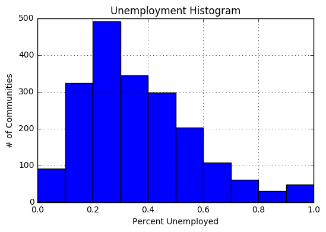

```python
popDensMean = data['PopDens'].mean()
print("The mean population density for the communities in this dataset is: " + str(popDensMean))
print("\n")
popDensMed = data['PopDens'].median()
print("The median population density for the communities in this dataset is: " + str(popDensMed))
print("\n")
popDensMean = data['PctRecImmig10'].mean()
print("The mean of the percentage of immigrants within the last 10 yers in this dataset is: " + str(popDensMean))
print("\n")
popDensMed = data['PctRecImmig10'].median()
print("The median of the percentage of immigrants within the last 10 years in this dataset is: " + str(popDensMed))
print("\n")
popVar = pd.DataFrame.var(data['PopDens'])
print("The variance for the population density is: " + str(popVar))
print("\n")
print("Here we have a histogram showing the distribution of the percent of unemployed individuals:")
print("\n")
pd.DataFrame.hist(data, column=['PctUnemployed'])
plt.xlabel("Percent Unemployed")
plt.ylabel("# of Communities")
plt.title("Unemployment Histogram")
plt.show()
```

For predicting things like important attributes for Machine Learning aglorithms, it is good practice to guess important features and plot them across what you want to predict on. In our case, it is CrimeRatePerPop, or Crime Rate Per Community.

Within the graph is a line of best fit using NumPy's polyfit object.

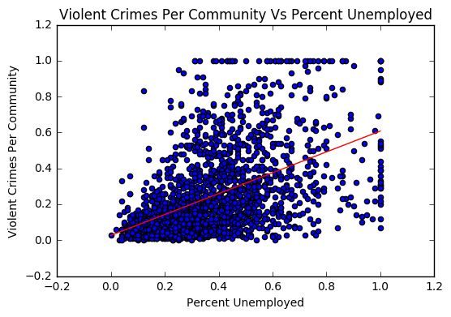

```
There is a positive linear coefficient of 0.581086766789 which means there exists a positive linear relationship between the amount of unemployed people and violent crime rates in that community.
```

```python
plt.scatter(data['PctUnemployed'], data['ViolentCrimesPerPop'])
plt.xlabel('Percent Unemployed')
plt.ylabel('Violent Crimes Per Community')
plt.title('Violent Crimes Per Community Vs Percent Unemployed')
plt.plot(np.unique(data['PctUnemployed']), np.poly1d(np.polyfit(data['PctUnemployed'], data['ViolentCrimesPerPop'], 1))(np.unique(data['PctUnemployed'])),color='r')
line = np.polyfit(data['PctUnemployed'], data['ViolentCrimesPerPop'], 1)
plt.show()
print("There is a positive linear coefficient of " + str(line[0]) + " which means there exists a positive linear relationship between the amount of unemployed people and violent crime rates in that community.")
```

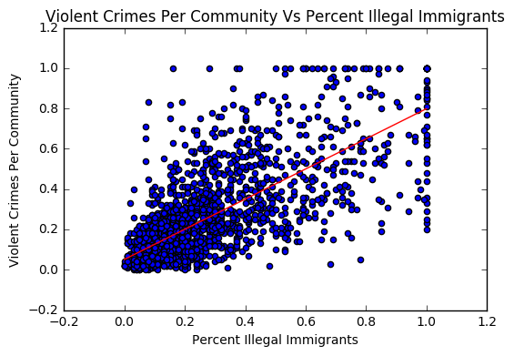

```
There is a positive linear coefficient of 0.747708820594 which means there exists a positive linear relationship between the amount of illegal immigrants and violent crime rates in that community.
```

```python
plt.scatter(data['PctIlleg'], data['ViolentCrimesPerPop'])
plt.xlabel('Percent Illegal Immigrants')
plt.ylabel('Violent Crimes Per Community')
plt.title('Violent Crimes Per Community Vs Percent Illegal Immigrants')
plt.plot(np.unique(data['PctIlleg']), np.poly1d(np.polyfit(data['PctIlleg'], data['ViolentCrimesPerPop'], 1))(np.unique(data['PctIlleg'])),color='r')
line = (np.polyfit(data['PctIlleg'], data['ViolentCrimesPerPop'], 1))
plt.show()
print("There is a positive linear coefficient of " + str(line[0]) + " which means there exists a positive linear relationship between the amount of illegal immigrants and violent crime rates in that community.")
```

### Step 4: Analysis, Hypothesis testing & Machine Learning

Analysis and Machine Learning are very important in data science. Sometimes people need to predict values or classify things for many purposes. For this tutorial, we will show you how to predict violent crime rates for each community in our data based on the 100 remaining attributes, because communityname should not help with predictions and ViolentCrimesPerPop is what we are trying to predict. We had 1994 rows of data, we chose a random subset of 80% of the data for training data, and the remaining 20% was used to test our regression.

#### Regression

We choose to use two types of linear regression and two types of non-linear to see if the data was linear. The regressions we did were: Linear Regression, Stochastic Gradient Descent Regression, Extra Trees, and Random Forests. Linear regression uses ordinary least squares to fit a line to the data. Stochastic gradient descent mimimizes squared loss while adding a regularizing penalty function to promote sparsity in the weight vector. Specifically, we used the elastic net penalty function, which is a combination of an L1 and L2 loss function. For further reading on how this function works, please see [this link](http://scikit-learn.org/stable/modules/generated/sklearn.linear_model.SGDRegressor.html). Extra Trees and Random Forests combine a set of randomized decision trees on various subsets of the data. They average these models to help with over-fitting and improve accuracy. Random Forests differ from Extra Trees in how they choose to split and sample the data given. Extra Trees tend to have more leaves, while Random Forests allow for sampling with replacement.

#### Goal

We want to build a model that uses the features to predict the ViolentCrimesPerPop: total number of violent crimes per 100K popuation data. The tree models we used (Extra Trees and Random Forests) also provide the "most important" features used to make these predictions.

#### Hypothesis

We believe that the most important features will be the percent of unemployed per community and the percent of illegal immigrants per community, due to their strong positive linear relationships

[figure not shown]

Since they provide us with the ViolentCrimesPerPop column (the one we want to predict), we will drop it from our DataFrame, and store it in a variable for future comparison. We create a new reference to the data. We are going to drop two columns, 'communityname' and 'ViolentCrimesPerPop'. The first is a string which is a geographic location and will not be necessary for machine learning. The second is what we will be predicting, so we remove it. We reshape our dataframe into a matrix for computing expected values of 'ViolentCrimesPerPop'.

```python
violentCrimesPerPop = data['ViolentCrimesPerPop']
violentCrimesPerPop = violentCrimesPerPop.as_matrix().flatten() #y-value
violentCrimesSave = violentCrimesPerPop
#Create
data_df = data
data_arr = data.drop(['communityname','ViolentCrimesPerPop'],1).as_matrix().flatten().reshape(1994,100)
data_arr = data_arr.astype(np.float)
```

It is good practice to use 80% of your data for training your model and 20% to test your model. The below code splits our data into training data and testing data. This is how we will train and explore our machine learning algorithms.

```python
rand_permute = np.random.permutation(len(data_arr))
data_arr = data_arr[rand_permute,:]
violentCrimesPerPop = violentCrimesPerPop[rand_permute]

training_size = int(np.floor(len(data_arr)*.8))
test_size = len(data_arr) - training_size

training_data_arr = data_arr[0:training_size,:]
training_violent_crimes = violentCrimesPerPop[0:training_size]

test_data_arr = data_arr[training_size+1:-1,:]
test_violent_crimes = violentCrimesPerPop[training_size+1:-1]
```

We will use linear regression, stochastic gradient descent regression, extra trees regression, and random forests for our machine learning process. We also sort the feature importances that we calculated using the extra trees and random forest regressor's.

```python
from sklearn import linear_model
from sklearn.linear_model import SGDRegressor
from sklearn.preprocessing import StandardScaler
from sklearn.tree import DecisionTreeRegressor
from sklearn.ensemble import ExtraTreesRegressor
from sklearn.ensemble import RandomForestRegressor
from IPython.core import display as ICD
from IPython.display import display, HTML

reg = linear_model.LinearRegression()
reg.fit(training_data_arr, training_violent_crimes)
linear_model.LinearRegression(copy_X=True, fit_intercept=True, n_jobs=1, normalize=False)

#Stochastic Gradient Descent
SGD = SGDRegressor(penalty='elasticnet')
SGD = SGD.fit(training_data_arr, training_violent_crimes)

#Extra Tree Regressor
ETReg = ExtraTreesRegressor()
ETReg.fit(training_data_arr, training_violent_crimes)

#Find most valuable feature for predicting crime rates
a = ETReg.feature_importances_
sorted_indET = np.argsort(a)

#Random Forest Regressor
RFReg = RandomForestRegressor()
RFReg.fit(training_data_arr, training_violent_crimes)

#Find most valuable feature for predicting crime rates
b = RFReg.feature_importances_
sorted_indRF = np.argsort(b)

_datacrimePredictRFReg = RFReg.predict(test_data_arr)
_datacrimePredictETReg = ETReg.predict(test_data_arr)
_datacrimePredictSGD = SGD.predict(test_data_arr)
_datacrimePredictLinReg = reg.predict(test_data_arr)
```

### Step 5: Insight and Policy Decision

#### Insight

Being able to predict things accurately has almost unlimited potential. The applications of these prediction models are endless, from economics to politics, as well as many other fields. With such versatility and adaptivness prediction models can ultimately benefit a vast number of fields making it extremely useful. After our calculations, we now have four working prediction models.

#### Policy Decision

Machine learning gives us the information we need to make better buisness decisions, police certain areas more, where to move, where to build property, etc.

[figure not shown]

In the below code we are calculating the regression scores of four different models including Linear Regression, Stochastic Gradient Descent, Extra Tree Regression, as well as Random Forest Regression. Below we made a dataframe that holds the R<sup>2</sup> values otherwise known as the coefficent of determination. The data is sorted.

```python
#Create score DataFrame
scoreList = [reg.score(test_data_arr, test_violent_crimes), SGD.score(test_data_arr, test_violent_crimes),ETReg.score(test_data_arr, test_violent_crimes),RFReg.score(test_data_arr, test_violent_crimes)]
scoreCols = ['Linear Regression','Stochastic Gradient Descent', 'Extra Tree Regression', 'Random Forest Regression']
scoreDF = pd.DataFrame(scoreList)
scoreDF.columns = ['Scores for Regressions']
scoreDF.index = scoreCols
scoreDF = scoreDF.sort_values(ascending=False,by='Scores for Regressions')
ICD.display(scoreDF)
```

|  | Scores for Regressions |
| --- | --- |
| Linear Regression | 0.691538 |
| Extra Tree Regression | 0.690901 |
| Random Forest Regression | 0.659559 |
| Stochastic Gradient Descent | 0.659341 |

This code below shows the r value, otherwise known as the correlation statistic, of Extra Tree Regression, Stochastic Gradient Descent, Linear Regression, and Random Forest Regression. Additionally this code stores those values in descending order.

```python
import math
#Create R value DataFrame
scoreList2 = [math.sqrt(reg.score(test_data_arr, test_violent_crimes)), math.sqrt(SGD.score(test_data_arr, test_violent_crimes)),math.sqrt(ETReg.score(test_data_arr, test_violent_crimes)),math.sqrt(RFReg.score(test_data_arr, test_violent_crimes))]
scoreCols2 = ['Linear Regression','Stochastic Gradient Descent', 'Extra Tree Regression', 'Random Forest Regression']
scoreDF2 = pd.DataFrame(scoreList2)
scoreDF2.columns = ['R Values for Regressions']
scoreDF2.index = scoreCols
scoreDF2 = scoreDF2.sort_values(ascending=False,by='R Values for Regressions')
ICD.display(scoreDF2)
```

|  | R Values for Regressions |
| --- | --- |
| Linear Regression | 0.831587 |
| Extra Tree Regression | 0.831205 |
| Random Forest Regression | 0.812133 |
| Stochastic Gradient Descent | 0.811998 |

In this code below we store the feature importances of the top five features in a dataframe from highest to lowest. These features hold the probability weight of occurence per branch.

```python
#Create a Extra Tree Regressor feature importance dataframe
etDF = pd.DataFrame(a[sorted_indET[-5:]], columns=['Feature Importance of Extra Tree Regressor'])
etDF.index = data_df.columns[sorted_indET[-5:]]
etDF = etDF.sort_values(ascending=False, by='Feature Importance of Extra Tree Regressor')
ICD.display(etDF)
```

|  | Feature Importance of Extra Tree Regressor |
| --- | --- |
| NumIlleg | 0.220725 |
| PctFam2Par | 0.118921 |
| PersPerFam | 0.082288 |
| racepctblack | 0.074830 |
| PctWorkMom | 0.054456 |

Similarly to the last regression done above this code stores the feature importances of the top five features in a dataframe from highest to lowest. These features also hold the probability weight of occurence per branch.

```python
#Create a Random Forest Regressor feature importance dataframe
rfDF = pd.DataFrame(b[sorted_indRF[-5:]], columns=['Feature Importance of Random Forest Regressor'])
rfDF.index = data_df.columns[sorted_indRF[-5:]]
rfDF = rfDF.sort_values(ascending=False, by='Feature Importance of Random Forest Regressor')
ICD.display(rfDF)
```

|  | Feature Importance of Random Forest Regressor |
| --- | --- |
| NumIlleg | 0.470458 |
| PctFam2Par | 0.077197 |
| racepctblack | 0.019887 |
| MalePctNevMarr | 0.019206 |
| PersPerFam | 0.019072 |

```python
#Create dataframe for comparing true violent crimes per pop vs our predictions
compDF = data.loc[rand_permute[training_size+1:-1],:]
compDF
compDF = compDF[[-1]]
compDF['crimePredictRFReg'] = _datacrimePredictRFReg
compDF['crimePredictETReg'] = _datacrimePredictETReg
compDF['crimePredictSGD'] = _datacrimePredictSGD
compDF['crimePredictLinReg'] = _datacrimePredictLinReg
compDF = compDF[[1, 2, 3, 4, 0]]
compDF = compDF.rename(columns = {'ViolentCrimesPerPop':'Actual_Crime_Rates'})
compDF.sample(20)
```

|  | crimePredictRFReg | crimePredictETReg | crimePredictSGD | crimePredictLinReg | Actual_Crime_Rates |
| --- | --- | --- | --- | --- | --- |
| 555 | 0.752 | 0.466 | 0.615869 | 0.661212 | 0.55 |
| 480 | 0.057 | 0.056 | 0.048718 | -0.021501 | 0.40 |
| 243 | 0.580 | 0.592 | 0.520889 | 0.625558 | 0.54 |
| 1278 | 0.064 | 0.066 | 0.107621 | 0.064135 | 0.14 |
| 582 | 0.189 | 0.167 | 0.214657 | 0.136480 | 0.27 |
| 1248 | 0.635 | 0.599 | 0.649393 | 0.594843 | 0.03 |
| 416 | 0.432 | 0.385 | 0.452251 | 0.454669 | 0.01 |
| 744 | 0.077 | 0.094 | 0.065222 | -0.003639 | 0.01 |
| 1114 | 0.159 | 0.120 | 0.167454 | 0.152151 | 0.05 |
| 933 | 0.258 | 0.256 | 0.432368 | 0.426990 | 0.10 |
| 241 | 0.524 | 0.455 | 0.442207 | 0.474923 | 0.12 |
| 1184 | 0.068 | 0.082 | 0.080457 | 0.110785 | 0.08 |
| 790 | 0.060 | 0.071 | 0.073846 | 0.053461 | 0.18 |
| 1778 | 0.116 | 0.109 | 0.181810 | 0.110041 | 0.48 |
| 620 | 0.074 | 0.110 | 0.131020 | 0.062413 | 0.33 |
| 1917 | 0.158 | 0.313 | 0.324459 | 0.265407 | 0.20 |
| 1506 | 0.064 | 0.060 | 0.064371 | 0.052878 | 0.55 |
| 1480 | 0.057 | 0.068 | 0.073569 | 0.017628 | 0.37 |
| 1443 | 0.289 | 0.335 | 0.332011 | 0.311283 | 0.14 |
| 734 | 0.084 | 0.109 | 0.095150 | 0.161560 | 0.10 |

In this code below we computed the actual - expected value for crimePredictLinReg, crimePredictSGD, crimePredictETReg, crimePredictRFReg and stored it in the dataframe, to show how close the predictions were to the actual values.

```python
#Create differences from actual - each regression
import operator
CPLR_difference = list(map(operator.sub, compDF['Actual_Crime_Rates'], compDF['crimePredictLinReg']))
CPSGD_difference = list(map(operator.sub, compDF['Actual_Crime_Rates'], compDF['crimePredictSGD']))
CPETR_difference =list(map(operator.sub, compDF['Actual_Crime_Rates'], compDF['crimePredictETReg']))
CPRFR_difference = list(map(operator.sub, compDF['Actual_Crime_Rates'], compDF['crimePredictRFReg']))
data_ = [CPLR_difference, CPSGD_difference, CPETR_difference, CPRFR_difference]
columns = ["CPLR_differnce","CPSGD_difference", "CPETR_difference", "CPRFR_difference"]
diffDF = pd.DataFrame(data_).T
diffDF.columns=columns
diffDF.head(20)
```

|  | CPLR_differnce | CPSGD_difference | CPETR_difference | CPRFR_difference |
| --- | --- | --- | --- | --- |
| 0 | 0.029408 | 0.008012 | -0.049 | 0.003 |
| 1 | 0.188010 | 0.180017 | 0.170 | 0.157 |
| 2 | 0.249748 | 0.196733 | 0.312 | 0.309 |
| 3 | 0.376555 | 0.312556 | 0.322 | 0.245 |
| 4 | -0.095690 | -0.132107 | -0.070 | -0.091 |
| 5 | -0.108133 | -0.147095 | -0.124 | -0.104 |
| 6 | 0.265828 | 0.218551 | 0.268 | 0.266 |
| 7 | -0.071388 | -0.107254 | -0.088 | -0.171 |
| 8 | 0.133889 | 0.101565 | 0.171 | 0.144 |
| 9 | 0.184789 | 0.141996 | 0.165 | 0.168 |
| 10 | 0.386408 | 0.444788 | 0.490 | 0.496 |
| 11 | -0.359231 | -0.336910 | -0.383 | -0.330 |
| 12 | 0.034461 | -0.002604 | 0.008 | 0.011 |
| 13 | -0.265223 | -0.258732 | -0.244 | -0.234 |
| 14 | -0.176579 | -0.229244 | -0.157 | -0.165 |
| 15 | 0.378318 | 0.389441 | 0.300 | 0.346 |
| 16 | 0.497122 | 0.485629 | 0.490 | 0.486 |
| 17 | -0.017580 | -0.075669 | -0.028 | -0.002 |
| 18 | 0.099209 | 0.127846 | 0.121 | 0.092 |
| 19 | 0.219739 | 0.140316 | 0.242 | 0.182 |

Here we are outputting a dataframe of the mean of each difference column from the above dataframe.

```python
#Sorted mean values of differences
d = [diffDF["CPLR_differnce"].mean(),diffDF["CPSGD_difference"].mean(), diffDF["CPETR_difference"].mean(), diffDF["CPRFR_difference"].mean()]
d = pd.DataFrame(d)
columns = ["Linear Regression","Stochastic Gradient Descent", "Extra Trees Regression", "Random Forest Regression"]
d.index = columns
d.columns = ['Difference to Actual']
d.sort_values(ascending=False, inplace=True, by='Difference to Actual')
d
```

|  | Difference to Actual |
| --- | --- |
| Extra Trees Regression | -0.022710 |
| Linear Regression | -0.024337 |
| Random Forest Regression | -0.025854 |
| Stochastic Gradient Descent | -0.037144 |

For the above dataframe, the closer to zero, the more accurate the regression is.

If we had a lot more data and no missing values, we would not have to impute values. Imputing values could potentially decrease accuracy of the model predictions. It is incredible how we can train the first 80% of our data, then test our model on the remaining 20% of unseen data.

For further reading on some topics we discussed, see the following and the references therein:

- [Linear Regression](http://scikit-learn.org/stable/modules/generated/sklearn.linear_model.LinearRegression.html)
- [Random Forests](http://scikit-learn.org/stable/modules/generated/sklearn.ensemble.RandomForestRegressor.html)
- [Extra Trees](http://scikit-learn.org/stable/modules/generated/sklearn.ensemble.ExtraTreesRegressor.html)
- [Stochastic Gradient Descent](http://scikit-learn.org/stable/modules/sgd.html)